# rapr: Representative and Adequate Prioritisations in R

### Uncertainty in species’ distributions

The unreliable formulation does not consider the probability that the planning units are occupied by features when calculating how well a given solution secures a representative sample of an attribute space. Thus solutions identified using the unreliable formulation may represent regions of an attribute space for a species using planning units only have a small chance of being occupied by the species. As a consequence, if the prioritisation is implemented, it may fail to secure regions of an attribute space if individuals do not inhabit these planning units, and ultimately fail to fulfil the space targets.

A simple solution to this issue would be to ensure that planning units cannot be assigned to demand points if they have a low probability of occupancy. This can be acheived by setting a probability threshold for planning units, such that planning units with a probability of occupancy below the threshold are effectively set to zero.

```r
# make new prioritisation with probability threshold of 0.5 for each species
sim_mrs_space2 <- solve(
    prob.subset(
        sim_mrs_space,
        species=1:3,
        threshold=c(0.5,0.5,0.5)
    )
)
```

```
## Optimize a model with 14706 rows, 14500 columns and 57744 nonzeros
## Coefficient statistics:
##   Matrix range    [1e-05, 8e+00]
##   Objective range [1e+00, 1e+00]
##   Bounds range    [1e+00, 1e+00]
##   RHS range       [1e+00, 5e+01]
## Presolve time: 2.17s
## Presolved: 14706 rows, 14500 columns, 57558 nonzeros
## Variable types: 0 continuous, 14500 integer (14500 binary)
## Found heuristic solution: objective 100.0000000
## Found heuristic solution: objective 89.0000000
## Presolved: 14706 rows, 14500 columns, 57558 nonzeros
##
##
## Root simplex log...
##
## Iteration    Objective       Primal Inf.    Dual Inf.      Time
##     4588    2.0000296e+01   8.294983e+01   0.000000e+00      5s
##     5162    2.0000000e+01   0.000000e+00   0.000000e+00      5s
##     5162    2.0000000e+01   0.000000e+00   0.000000e+00      5s
##
## Root relaxation: objective 2.000000e+01, 5162 iterations, 3.02 seconds
##
##     Nodes    |    Current Node    |     Objective Bounds      |     Work
##  Expl Unexpl |  Obj  Depth IntInf | Incumbent    BestBd   Gap | It/Node Time
##
## *    0     0               0      20.0000000   20.00000  0.00%     -    6s
##
## Explored 0 nodes (7118 simplex iterations) in 6.65 seconds
## Thread count was 1 (of 2 available processors)
##
## Optimal solution found (tolerance 5.00e-02)
## Best objective 2.000000000000e+01, best bound 2.000000000000e+01, gap 0.0%
```

```r
# show summary
summary(sim_mrs_space2)
```

```
##   Run_Number Score Cost Planning_Units Connectivity_Total Connectivity_In
## 1          1    20   20             20                220               7
##   Connectivity_Edge Connectivity_Out Connectivity_In_Fraction
## 1               144               69               0.03181818
```

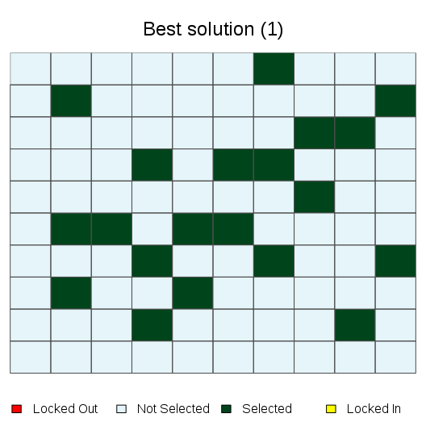

```r
# plot prioritisation
plot(sim_mrs_space2, 1)
```

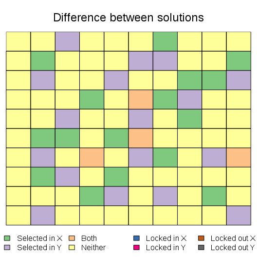

```r
# difference between prioritisations that use and do not use thresholds
plot(sim_mrs_space2, sim_mrs_space, 1, 1, main='Difference between solutions')
```

But this method requires setting somewhat arbitrary thresholds. A more objective solution to this issue would be to actually use the probability that species occupy planning units to generate the prioritisations–this is what the reliable formulation does. Now we will generate a prioritisation using the reliable formulation. To reduce computational time, we will set the maximum backup $R$-level to 1.

```r
# make new prioritisation using reliable formulation
sim_mrs_space3 <- update(sim_mrs_space, formulation='reliable', max.r.level=1L)
```

```
## Optimize a model with 364206 rows, 181900 columns and 3847800 nonzeros
## Coefficient statistics:
##   Matrix range    [1e-05, 1e+02]
##   Objective range [1e+00, 1e+00]
##   Bounds range    [1e+00, 1e+00]
##   RHS range       [7e-03, 7e+02]
## Presolve removed 333500 rows and 90800 columns (presolve time = 5s) ...
## Presolve removed 333700 rows and 151600 columns (presolve time = 10s) ...
## Presolve removed 333700 rows and 151600 columns (presolve time = 15s) ...
## Presolve removed 333700 rows and 151600 columns (presolve time = 141s) ...
## Presolve removed 333700 rows and 151600 columns
## Presolve time: 144.01s
## Presolved: 30506 rows, 30300 columns, 139889 nonzeros
## Variable types: 200 continuous, 30100 integer (30100 binary)
## Found heuristic solution: objective 100.0000000
## Presolved: 30506 rows, 30300 columns, 139889 nonzeros
##
##
## Root simplex log...
##
## Iteration    Objective       Primal Inf.    Dual Inf.      Time
##        0    0.0000000e+00   3.744712e+02   0.000000e+00    149s
##     2937    2.0000038e+01   8.060854e+01   0.000000e+00    150s
##     5235    2.0000000e+01   0.000000e+00   0.000000e+00    153s
##     5235    2.0000000e+01   0.000000e+00   0.000000e+00    153s
##
## Root relaxation: objective 2.000000e+01, 5235 iterations, 5.35 seconds
## Total elapsed time = 155.23s
##
##     Nodes    |    Current Node    |     Objective Bounds      |     Work
##  Expl Unexpl |  Obj  Depth IntInf | Incumbent    BestBd   Gap | It/Node Time
##
## *    0     0               0      20.0000000   20.00000  0.00%     -  155s
##
## Explored 0 nodes (8001 simplex iterations) in 156.14 seconds
## Thread count was 1 (of 2 available processors)
##
## Optimal solution found (tolerance 5.00e-02)
## Best objective 2.000000000000e+01, best bound 2.000000000000e+01, gap 0.0%
```

```r
# show summary
summary(sim_mrs_space3)
```

```
##   Run_Number Score Cost Planning_Units Connectivity_Total Connectivity_In
## 1          1    20   20             20                220               9
##   Connectivity_Edge Connectivity_Out Connectivity_In_Fraction
## 1               144               67               0.04090909
```

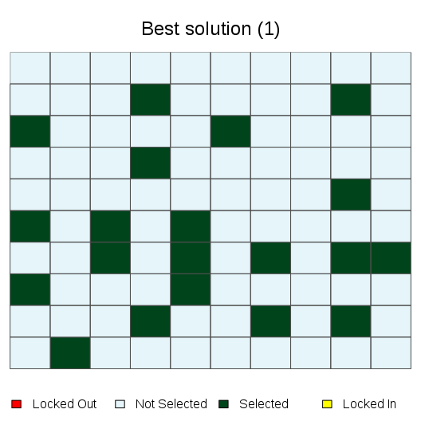

```r
# plot prioritisation
plot(sim_mrs_space3, 1)
```

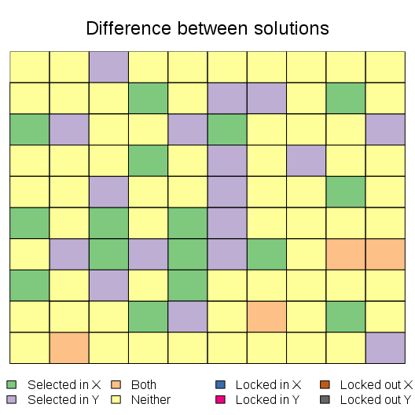

```r
# difference between prioritisations based on unreliable and reliable formulation
plot(sim_mrs_space3, sim_mrs_space, 1, 1, main='Difference between solutions')
```

### Distance metrics

In the previous examples, we have only used Euclidean distances to determine how much a prioritisation samples a set of demand points in an attribute space. However, Euclidean distances can be poor measures of distance for multivariate, binary, or correlated variables (Faith *et al.* 1987). As a consequence this may lead to over- or under-estimates of how well a given prioritisation samples an attribute space.

The `rapr` R package provides a suite of distance metrics that can be used to calculate spatial representation. To illustrate how using different distance metrics can affect the the optimal solution, we will generate a new suite of prioritisations using different distance metrics.

First, we will simulate a new species and a three-dimensional attribute space. Note that unlike the previous examples, the attribute space will not be geographic space. Rather, the each dimension in the attribute space will have values that map onto geographic space (eg. like climatic variables across the landscape). To add further complexity, we simulate their distributions using Gaussian processes.

```r
# load RandomFields package and set seed for simulations
library(RandomFields)
set.seed(500)

# simulate planning units
sim_pus <- sim.pus(25L)

# simulate species
sim_gspp <- sim.species(sim_pus, model=RPgauss(), n=1, res=0.1)

# simulate space
sim_gspace <- sim.space(sim_pus, model=RMgauss(scale=3), d=3, res=0.1)
```

```
## ...
```

```r
# generate RapUnsolved object containing data to generate prioritisations
sim_gru <- rap(
    sim_pus, sim_gspp, sim_gspace,
    amount.target=0.2, space.target=0.85,
    n.demand.points=50L, kernel.method='hypervolume',
    include.geographic.space=FALSE, solve=FALSE
)
```

```
## Choosing repsperpoint=1500 (use a larger value for more accuracy.)
## Evaluating probability density...
## Building tree... done.
## Querying tree... 2.33918e-06  0.0233942  0.046786  0.0701778  0.0935696  0.116961  0.140353  0.163745  0.187137  0.210529  0.23392  0.257312  0.280704  0.304096  0.327488  0.35088  0.374271  0.397663  0.421055  0.444447  0.467839  0.49123  0.514622  0.538014  0.561406  0.584798  0.608189  0.63158…
## Finished evaluating probability density.
## Beginning volume calculation... done.
## Quantile requested: 0.20   obtained: 0.20
```

Let’s visualise the species’ distribution and the distribution of the attribute space across geographic space.

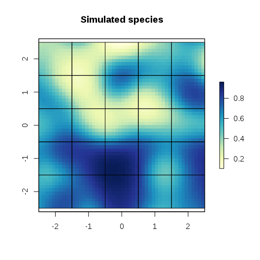

```r
# plot species distribution
plot(
    sim_gspp,
    main='Simulated species',
    col=colorRampPalette(c("#FFFFD9", "#EDF8B1", "#C7E9B4", "#7FCDBB",
        "#41B6C4", "#1D91C0", "#225EA8", "#253494", "#081D58"
    ))(100)
)
lines(sim_pus)
```

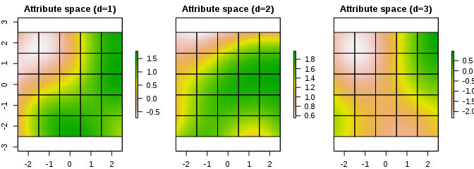

```r
# plot distribution of each dimension in the attribute space across geographic space
plot(
    sim_gspace,
    main=c('Attribute space (d=1)', 'Attribute space (d=2)', 'Attribute space (d=3)'),
    addfun=function(){lines(sim_pus)},
    nc=3
)
```

For each different distance metric, we will update the `sim_gru` object with the new distance metric, solve it, and store the solution in a list.

```r
# create vector with distance metrics
dist.metrics <- c(
    'euclidean', 'bray', 'manhattan','gower',
    'canberra', 'mahalanobis',
    'jaccard', 'kulczynski'
)

# generate solutions
solutions <- list()
for (i in dist.metrics) {
    solutions[[i]] <- update(sim_gru, distance.metric=i)
}
```

```
## Optimize a model with 1302 rows, 1275 columns and 5025 nonzeros
## Coefficient statistics:
##   Matrix range    [3e-01, 3e+02]
##   Objective range [1e+00, 1e+00]
##   Bounds range    [1e+00, 1e+00]
##   RHS range       [1e+00, 8e+02]
## Presolve removed 8 rows and 0 columns
## Presolve time: 0.09s
## Presolved: 1294 rows, 1275 columns, 4998 nonzeros
## Variable types: 0 continuous, 1275 integer (1275 binary)
## Found heuristic solution: objective 21.0000000
## Found heuristic solution: objective 19.0000000
## Presolved: 1294 rows, 1275 columns, 4998 nonzeros
##
##
## Root relaxation: objective 4.056382e+00, 1423 iterations, 0.12 seconds
##
##     Nodes    |    Current Node    |     Objective Bounds      |     Work
##  Expl Unexpl |  Obj  Depth IntInf | Incumbent    BestBd   Gap | It/Node Time
##
##      0     0    4.05638    0  102   19.00000    4.05638  78.7%     -    0s
## H    0     0                       8.0000000    4.05638  49.3%     -    0s
## H    0     0                       5.0000000    4.05638  18.9%     -    0s
##
## Explored 0 nodes (1423 simplex iterations) in 0.25 seconds
## Thread count was 1 (of 2 available processors)
##
## Optimal solution found (tolerance 5.00e-02)
## Best objective 5.000000000000e+00, best bound 5.000000000000e+00, gap 0.0%
## Optimize a model with 1302 rows, 1275 columns and 5025 nonzeros
## Coefficient statistics:
##   Matrix range    [3e-01, 3e+05]
##   Objective range [1e+00, 1e+00]
##   Bounds range    [1e+00, 1e+00]
##   RHS range       [1e+00, 3e+04]
## Found heuristic solution: objective 21
## Presolve removed 2 rows and 1 columns
## Presolve time: 0.05s
## Presolved: 1300 rows, 1274 columns, 3772 nonzeros
## Variable types: 0 continuous, 1274 integer (1274 binary)
```

[output cut: 181 more lines]

```
##
## Root relaxation: objective 3.289598e+00, 1239 iterations, 0.09 seconds
##
##     Nodes    |    Current Node    |     Objective Bounds      |     Work
##  Expl Unexpl |  Obj  Depth IntInf | Incumbent    BestBd   Gap | It/Node Time
##
##      0     0    3.28960    0  120   21.00000    3.28960  84.3%     -    0s
## H    0     0                       7.0000000    3.28960  53.0%     -    0s
## H    0     0                       4.0000000    3.28960  17.8%     -    0s
##
## Explored 0 nodes (1239 simplex iterations) in 0.19 seconds
## Thread count was 1 (of 2 available processors)
##
## Optimal solution found (tolerance 5.00e-02)
## Best objective 4.000000000000e+00, best bound 4.000000000000e+00, gap 0.0%
```

Now, let’s plot the solutions to see how they differ.

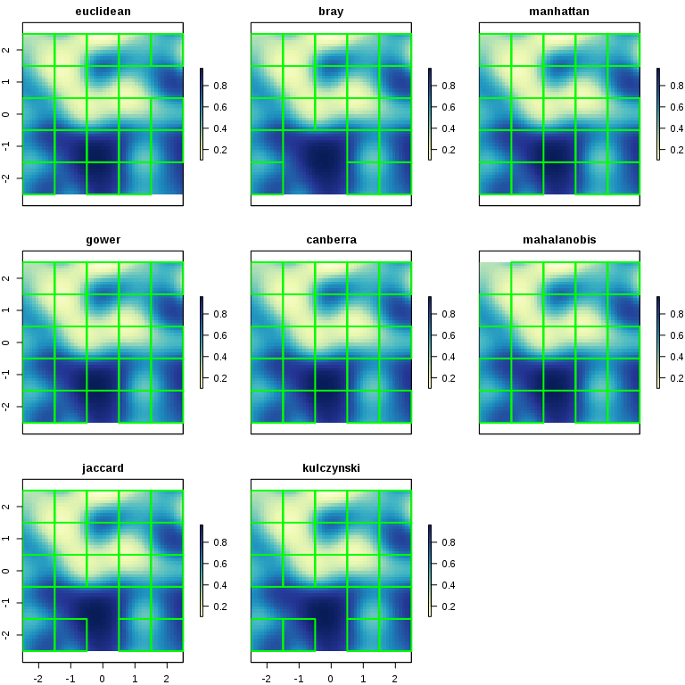

```r
# set counter for plotting
counter <- 1

# create plots showing the selected planning units (green) using each metric
plot(
    stack(replicate(list(sim_gspp), n=length(dist.metrics))),
    main=dist.metrics,
    col=colorRampPalette(c("#FFFFD9", "#EDF8B1", "#C7E9B4", "#7FCDBB",
        "#41B6C4", "#1D91C0", "#225EA8", "#253494", "#081D58"
    ))(100),
    addfun=function() {
        lines(sim_pus[selections(solutions[[counter]])==0,])
        lines(sim_pus[selections(solutions[[counter]])==0,], col='green', lwd=2)
        counter <<- counter + 1
    }
)
```